# Organizing and Processing Point Count Data

Peter Solymos solymos@ualberta.ca

## Preamble

```r
## mace a local copy of day 1 files
source("src/functions.R")
qpad_local(day=1)
```

```
##
## Files copied: work in your LOCAL copies
```

```r
library(mefa4)                # data manipulation
load("data/josm-data.rda")    # load bird data
```

## Cross tabulating species counts

Take the following dummy data frame (long format):

```r
(d <- data.frame(
  sample=factor(paste0("S", c(1,1,1,2,2)), paste0("S", 1:3)),
  species=c("BTNW", "OVEN", "CANG", "AMRO", "CANG"),
  abundance=c(1, 1, 2, 1, 1),
  behavior=rep(c("heard","seen"), c(4, 1)),
  stringsAsFactors=TRUE))
```

```
##   sample species abundance behavior
## 1     S1    BTNW         1    heard
## 2     S1    OVEN         1    heard
## 3     S1    CANG         2    heard
## 4     S2    AMRO         1    heard
## 5     S2    CANG         1     seen
```

```r
str(d)
```

```
## 'data.frame':    5 obs. of  4 variables:
##  $ sample   : Factor w/ 3 levels "S1","S2","S3": 1 1 1 2 2
##  $ species  : Factor w/ 4 levels "AMRO","BTNW",..: 2 4 3 1 3
##  $ abundance: num  1 1 2 1 1
##  $ behavior : Factor w/ 2 levels "heard","seen": 1 1 1 1 2
```

We want to add up the `abundance`s for each sample (rows) and species (column):

```r
(y <- Xtab(abundance ~ sample + species, d))
```

```
## 3 x 4 sparse Matrix of class "dgCMatrix"
##    AMRO BTNW CANG OVEN
## S1    .    1    2    1
## S2    1    .    1    .
## S3    .    .    .    .
```

`y` is a sparse matrix, that is a very compact representation because it does not store the 0 values (`.`).

It is called a

- wide format table,
- cross table,
- pivot table,
- 2-way table.

Notice that we have 3 rows, but `d$sample` did not have an `S3` value, but it was only a factor level without a corresponding observation.

We can drop such unused levels, but it is generally not recommended, and we need to be careful not to drop samples where no species was detected (this can happen quite often depending on timing of surveys).

```r
Xtab(abundance ~ sample + species, d, drop.unused.levels = TRUE)
```

```
## 2 x 4 sparse Matrix of class "dgCMatrix"
##    AMRO BTNW CANG OVEN
## S1    .    1    2    1
## S2    1    .    1    .
```

The current tendency is to treat such data as character. Let’s see what happens if we go with the flow and subset our data frame:

```r
d2 <- d
d2$sample <- as.character(d2$sample)
d2$species <- as.character(d2$species)
str(d2)
```

```
## 'data.frame':    5 obs. of  4 variables:
##  $ sample   : chr  "S1" "S1" "S1" "S2" ...
##  $ species  : chr  "BTNW" "OVEN" "CANG" "AMRO" ...
##  $ abundance: num  1 1 2 1 1
##  $ behavior : Factor w/ 2 levels "heard","seen": 1 1 1 1 2
```

```r
Xtab(abundance ~ sample + species, d2)
```

```
## 2 x 4 sparse Matrix of class "dgCMatrix"
##    AMRO BTNW CANG OVEN
## S1    .    1    2    1
## S2    1    .    1    .
```

```r
Xtab(abundance ~ sample + species, d2[d2$species=="OVEN",])
```

```
## 1 x 1 sparse Matrix of class "dgCMatrix"
##    OVEN
## S1    1
```

It is the same as dropping unused levels. Compare this to the output most of us want:

```r
Xtab(abundance ~ sample + species, d[d$species=="OVEN",], cdrop=TRUE)
```

```
## 3 x 1 sparse Matrix of class "dgCMatrix"
##    OVEN
## S1    1
## S2    .
## S3    .
```

A sparse matrix can be converted to ordinary matrix

```r
as.matrix(y)
```

```
##    AMRO BTNW CANG OVEN
## S1    0    1    2    1
## S2    1    0    1    0
## S3    0    0    0    0
```

We can take a subset that retains the matrix structure

```r
y[,"OVEN",drop=FALSE]
```

```
## 3 x 1 sparse Matrix of class "dgCMatrix"
##    OVEN
## S1    1
## S2    .
## S3    .
```

Dropping the dimension will lead to a numeric vector

```r
y[,"OVEN"]
```

```
## S1 S2 S3
##  1  0  0
```

The nice thing about this cross tabulation is that we can filter the records without changing the structure (rows, columns) of the table:

```r
Xtab(abundance ~ sample + species, d[d$behavior == "heard",])
```

```
## 3 x 4 sparse Matrix of class "dgCMatrix"
##    AMRO BTNW CANG OVEN
## S1    .    1    2    1
## S2    1    .    .    .
## S3    .    .    .    .
```

```r
Xtab(abundance ~ sample + species, d[d$behavior == "seen",])
```

```
## 3 x 4 sparse Matrix of class "dgCMatrix"
##    AMRO BTNW CANG OVEN
## S1    .    .    .    .
## S2    .    .    1    .
## S3    .    .    .    .
```

Another common way of preserving empty samples is to add a placeholder species called `"NONE"` to the data for the sample where no species were detected

```r
d3 <- (d <- data.frame(
  sample=factor(paste0("S", c(1,1,1,2,2,3)), paste0("S", 1:3)),
  species=c("BTNW", "OVEN", "CANG", "AMRO", "CANG", "NONE"),
  abundance=c(1, 1, 2, 1, 1, 0),
  behavior=c(rep(c("heard","seen"), c(4, 1)), NA),
  stringsAsFactors=FALSE))
str(d3)
```

```
## 'data.frame':    6 obs. of  4 variables:
##  $ sample   : Factor w/ 3 levels "S1","S2","S3": 1 1 1 2 2 3
##  $ species  : chr  "BTNW" "OVEN" "CANG" "AMRO" ...
##  $ abundance: num  1 1 2 1 1 0
##  $ behavior : chr  "heard" "heard" "heard" "heard" ...
```

```r
Xtab(abundance ~ sample + species, d3)
```

```
## 3 x 5 sparse Matrix of class "dgCMatrix"
##    AMRO BTNW CANG NONE OVEN
## S1    .    1    2    .    1
## S2    1    .    1    .    .
## S3    .    .    .    .    .
```

Now we have the `S3` sample in the cross table. The summary is that we need to be careful with filtering. We need to check to still have the full list of samples that we expect.

### Exercise

1. Try making crosstabs using different subsets of the data frames
2. Use row and column indices to make subsets
3. See what `rdrop=TRUE` or `cdrop=TRUE` does in the `Xtab()` call
4. See what happens if you omit the left-hand side of the formula (`Xtab(~ sample + species, d)`)
5. Try making a 3-way table (`Xtab(abundance ~ sample + species + behavior, d)`)

## Alberta data

The `josm` obeject is a list with 3 elements:

- `surveys`: data frame with survey specific information,
- `species`: lookup table for species,
- `counts`: individual counts by survey and species.

```r
names(josm)
```

```
## [1] "surveys" "species" "counts"
```

Species info: species codes, common and scientific names. The table could also contain taxonomic, trait, etc. information as well.

```r
head(josm$species)
```

```
##      SpeciesID        SpeciesName
## ALFL      ALFL   Alder Flycatcher
## AMBI      AMBI   American Bittern
## AMCO      AMCO      American Coot
## AMCR      AMCR      American Crow
## AMGO      AMGO American Goldfinch
## AMKE      AMKE   American Kestrel
##             ScientificName
## ALFL     Empidonax alnorum
## AMBI Botaurus lentiginosus
## AMCO      Fulica americana
## AMCR Corvus brachyrhynchos
## AMGO     Carduelis tristis
## AMKE      Falco sparverius
```

At the survey level, we have coordinates, date/time info, variables capturing survey conditions, and land cover info extracted from 1 km$^2$ resolution rasters.

```r
colnames(josm$surveys)
```

```
##  [1] "SiteID"        "SurveyArea"    "Longitude"
##  [4] "Latitude"      "Date"          "StationID"
##  [7] "ObserverID"    "TimeStart"     "VisitID"
## [10] "WindStart"     "PrecipStart"   "TempStart"
## [13] "CloudStart"    "WindEnd"       "PrecipEnd"
## [16] "TempEnd"       "CloudEnd"      "TimeFin"
## [19] "Noise"         "OvernightRain" "DateTime"
## [22] "SunRiseTime"   "SunRiseFrac"   "TSSR"
## [25] "OrdinalDay"    "DAY"           "Open"
## [28] "Water"         "Agr"           "UrbInd"
## [31] "SoftLin"       "Roads"         "Decid"
## [34] "OpenWet"       "Conif"         "ConifWet"
```

The count table contains one row for each unique individual of a species (`SpeciesID` links to the species lookup table) observed during a survey (`StationID` links to the survey attribute table).

```r
str(josm$counts)
```

```
## 'data.frame':    52372 obs. of  18 variables:
##  $ ObservationID: Factor w/ 57024 levels "CL10102-130622-001",..: 1 2 3 4 5 6 8 9 10 11 ...
##  $ SiteID       : Factor w/ 4569 levels "CL10102","CL10106",..: 1 1 1 1 1 1 1 1 2 2 ...
##  $ StationID    : Factor w/ 4569 levels "CL10102-1","CL10106-1",..: 1 1 1 1 1 1 1 1 2 2 ...
##  $ TimeInterval : int  1 1 1 1 5 5 1 1 1 1 ...
##  $ Direction    : int  1 2 2 2 1 4 4 4 1 1 ...
##  $ Distance     : int  1 2 2 1 3 3 2 1 1 1 ...
##  $ DetectType1  : Factor w/ 3 levels "C","S","V": 2 2 2 2 1 1 2 2 2 2 ...
##  $ DetectType2  : Factor w/ 3 levels "C","S","V": NA NA NA NA NA NA NA NA NA NA ...
##  $ DetectType3  : Factor w/ 3 levels "C","S","V": NA NA NA NA NA NA NA NA NA NA ...
##  $ Sex          : Factor w/ 4 levels "F","M","P","U": 2 2 2 2 4 4 2 2 2 2 ...
##  $ Age          : Factor w/ 6 levels "A","F","J","JUV",..: 1 1 1 1 1 1 1 1 1 1 ...
##  $ Activity1    : Factor w/ 17 levels "BE","CF","CH",..: 5 5 5 5 NA NA NA 5 5 NA ...
##  $ Activity2    : Factor w/ 17 levels "48","BE","CF",..: NA NA NA NA NA NA NA NA NA NA ...
##  $ Activity3    : Factor w/ 7 levels "CF","DC","DR",..: NA NA NA NA NA NA NA NA NA NA ...
##  $ ActivityNote : Factor w/ 959 levels "AGITATED","AGITATED CALLING",..: NA NA NA NA NA NA NA NA NA NA ...
##  $ Dur          : Factor w/ 3 levels "0-3min","3-5min",..: 1 1 1 1 3 3 1 1 1 1 ...
##  $ Dis          : Factor w/ 3 levels "0-50m","50-100m",..: 1 2 2 1 3 3 2 1 1 1 ...
##  $ SpeciesID    : Factor w/ 150 levels "ALFL","AMBI",..: 107 95 95 107 46 43 140 95 125 38 ...
```

### Crosstab

We have no abundance column, because each row stands for exactly one individual. We can add a column with 1’s, or we can just count the number of rows by using only the right-hand-side of the formula in `Xtab()`. `ytot` will be our total count matrix for now.

We also want to filter the records to contain only `S`ongs and `C`alls, without `V`visual detections:

```r
table(josm$counts$DetectType1, useNA="always")
```

```
##
##     C     S     V  <NA>
##  9180 41808  1384     0
```

We use `SiteID` for row names, because only 1 station and visit was done at each site:

```r
ytot <- Xtab(~ SiteID + SpeciesID,
             data = josm$counts[josm$counts$DetectType1 != "V",])
```

The reverse operation to `Xtab()` is `Melt()`:

```r
yrev <- Melt(ytot)
head(yrev)
```

```
##      rows cols value
## 1 CL10108 ALFL     2
## 2 CL10190 ALFL     1
## 3 CL11112 ALFL     1
## 4 CO10404 ALFL     1
## 5 CO10407 ALFL     1
## 6 CO12102 ALFL     1
```

```r
nrow(josm$counts[josm$counts$DetectType1 != "V",])
```

```
## [1] 50988
```

```r
nrow(yrev) # a lot less rows due to aggregating counts
```

```
## [1] 33655
```

See how not storing 0’s affect size compared to the long format and an ordinary wide matrix (use `yrev` to make the comparison fair, the original data frame contained a lot more info about the individual events, here we only compare the aggregated data)

```r
## 2-column data frame as reference
tmp <- as.numeric(object.size(yrev))
## spare matrix
as.numeric(object.size(ytot)) / tmp
```

```
## [1] 0.842021
```

```r
## dense matrix
as.numeric(object.size(as.matrix(ytot))) / tmp
```

```
## [1] 6.819952
```

```r
## matrix fill
sum(ytot > 0) / prod(dim(ytot))
```

```
## [1] 0.0491063
```

Check if counts are as expected:

```r
max(ytot) # this is interesting
```

```
## [1] 200
```

```r
sort(apply(as.matrix(ytot), 2, max)) # it is CANG
```

```
## BUFF BWTE COGO COHA DCCO GWTE HOLA NHOW NSHO RTHU
##    0    0    0    0    0    0    0    0    0    0
## WWSC CANV NOPI AMBI AMCO AMGO BAEA BAOR BEKI BOWA
##    0    0    0    1    1    1    1    1    1    1
## CONI CSWA EAPH GBHE GCTH GGOW GHOW HOWR LEOW MERL
##    1    1    1    1    1    1    1    1    1    1
## NESP NOGO NOHA NSWO PBGR RBGU RTHA SAVS SPSA WBNU
##    1    1    1    1    1    1    1    1    1    1
## BRBL CAGU MYWA SNBU VEER AMKE AMWI BADO BARS BBWO
##    1    1    1    1    1    2    2    2    2    2
## BHCO BLBW BLPW BLTE BWHA COGR DOWO EAKI HAWO KILL
##    2    2    2    2    2    2    2    2    2    2
## LEYE NAWA NOPO OSFL OSPR PIWO PUFI RNDU SORA SSHA
##    2    2    2    2    2    2    2    2    2    2
## COSN AMCR AMRO ATTW BHVI BOCH BRCR BTNW CMWA FOSP
##    2    3    3    3    3    3    3    3    3    3
## FRGU GCKI MAWR MOWA NOFL PHVI SACR SOSA SOSP SPGR
##    3    3    3    3    3    3    3    3    3    3
## TRES WETA WIWA WIWR YBSA FOTE BAWW BBWA BCCH BLJA
##    3    3    3    3    3    3    4    4    4    4
## CAWA CONW COTE GRYE NOWA NRWS OCWA REVI RNGR RUBL
##    4    4    4    4    4    4    4    4    4    4
## RWBL WAVI WEWP WISN YBFL YWAR ALFL AMRE CHSP CORA
##    4    4    4    4    4    4    5    5    5    5
## EVGR HETH LCSP RBGR RBNU RCKI SWSP CCSP COYE DEJU
##    5    5    5    5    5    5    5    6    6    6
## LEFL LISP MAWA OVEN RUGR SWTH BOGU MALL GRAJ PAWA
##    6    6    6    6    6    6    7    7    8    8
## WTSP YRWA COLO TEWA AMPI WWCR CEDW PISI RECR CANG
##    8    8    9   12   12   20   23   50   51  200
```

```r
## flyover (FO) flock (FL) beyond 100m distance
head(josm$counts[
  josm$counts$SiteID == rownames(ytot)[which(ytot[,"CANG"] == 200)] &
  josm$counts$SpeciesID == "CANG",])
```

```
##                         ObservationID  SiteID
## CO10712-130603-008 CO10712-130603-008 CO10712
## CO10712-130603-009 CO10712-130603-009 CO10712
## CO10712-130603-010 CO10712-130603-010 CO10712
## CO10712-130603-011 CO10712-130603-011 CO10712
## CO10712-130603-012 CO10712-130603-012 CO10712
## CO10712-130603-013 CO10712-130603-013 CO10712
##                    StationID TimeInterval Direction
## CO10712-130603-008 CO10712-1            1         2
## CO10712-130603-009 CO10712-1            1         2
## CO10712-130603-010 CO10712-1            1         2
## CO10712-130603-011 CO10712-1            1         2
## CO10712-130603-012 CO10712-1            1         2
## CO10712-130603-013 CO10712-1            1         2
##                    Distance DetectType1 DetectType2
## CO10712-130603-008        3           C        <NA>
## CO10712-130603-009        3           C        <NA>
## CO10712-130603-010        3           C        <NA>
## CO10712-130603-011        3           C        <NA>
## CO10712-130603-012        3           C        <NA>
## CO10712-130603-013        3           C        <NA>
##                    DetectType3 Sex Age Activity1
## CO10712-130603-008        <NA>   U   A        FO
## CO10712-130603-009        <NA>   U   A        FO
## CO10712-130603-010        <NA>   U   A        FO
## CO10712-130603-011        <NA>   U   A        FO
## CO10712-130603-012        <NA>   U   A        FO
## CO10712-130603-013        <NA>   U   A        FO
##                    Activity2 Activity3 ActivityNote
## CO10712-130603-008        FL      <NA>         <NA>
## CO10712-130603-009        FL      <NA>         <NA>
## CO10712-130603-010        FL      <NA>         <NA>
## CO10712-130603-011        FL      <NA>         <NA>
## CO10712-130603-012        FL      <NA>         <NA>
## CO10712-130603-013        FL      <NA>         <NA>
##                       Dur   Dis SpeciesID
## CO10712-130603-008 0-3min 100+m      CANG
## CO10712-130603-009 0-3min 100+m      CANG
## CO10712-130603-010 0-3min 100+m      CANG
## CO10712-130603-011 0-3min 100+m      CANG
## CO10712-130603-012 0-3min 100+m      CANG
## CO10712-130603-013 0-3min 100+m      CANG
```

We can check overall mean counts:

```r
round(sort(colMeans(ytot)), 4)
```

```
##   BUFF   BWTE   COGO   COHA   DCCO   GWTE   HOLA
## 0.0000 0.0000 0.0000 0.0000 0.0000 0.0000 0.0000
##   NHOW   NSHO   RTHU   WWSC   CANV   NOPI   GBHE
## 0.0000 0.0000 0.0000 0.0000 0.0000 0.0000 0.0002
##   GCTH   GHOW   LEOW   NOHA   RBGU   BRBL   CAGU
## 0.0002 0.0002 0.0002 0.0002 0.0002 0.0002 0.0002
##   AMCO   BAEA   BARS   NESP   NOGO   NOPO   NSWO
## 0.0004 0.0004 0.0004 0.0004 0.0004 0.0004 0.0004
##   RNDU   SNBU   VEER   BEKI   CSWA   MERL   SAVS
## 0.0004 0.0004 0.0004 0.0007 0.0007 0.0007 0.0007
##   SSHA   MYWA   AMKE   BAOR   OSPR   SPGR   WBNU
## 0.0007 0.0007 0.0009 0.0009 0.0009 0.0009 0.0009
##   AMGO   AMWI   BOWA   CONI   EAPH   HOWR   NRWS
## 0.0011 0.0011 0.0011 0.0011 0.0011 0.0011 0.0011
##   BLTE   COGR   EAKI   GGOW   NAWA   COSN   COTE
## 0.0013 0.0013 0.0013 0.0013 0.0013 0.0013 0.0015
##   FRGU   MAWR   FOTE   KILL   RTHA   BADO   BLBW
## 0.0015 0.0015 0.0015 0.0018 0.0020 0.0024 0.0024
##   AMBI   PBGR   SPSA   AMPI   BHCO   BWHA   SOSP
## 0.0028 0.0028 0.0028 0.0028 0.0031 0.0037 0.0042
##   RUBL   MALL   PUFI   DOWO   SORA   LEYE   ATTW
## 0.0044 0.0046 0.0048 0.0059 0.0068 0.0094 0.0096
##   HAWO   RNGR   BBWO   BLJA   BOGU   AMCR   EVGR
## 0.0101 0.0101 0.0107 0.0134 0.0140 0.0166 0.0169
##   RWBL   OSFL   LCSP   TRES   FOSP   WEWP   WIWA
## 0.0169 0.0186 0.0193 0.0201 0.0217 0.0232 0.0236
##   PIWO   RECR   SOSA   YWAR   GCKI   BLPW   CAWA
## 0.0256 0.0269 0.0269 0.0291 0.0304 0.0306 0.0315
##   SACR   BTNW   NOWA   OCWA   BRCR   CCSP   COLO
## 0.0322 0.0335 0.0341 0.0359 0.0381 0.0385 0.0387
##   PHVI   CONW   CEDW   RUGR   MOWA   WAVI   BCCH
## 0.0394 0.0429 0.0449 0.0475 0.0477 0.0582 0.0593
##   BOCH   NOFL   SWSP   GRYE   WWCR   AMRO   RBNU
## 0.0593 0.0622 0.0659 0.0685 0.0751 0.0757 0.0766
##   BBWA   CMWA   BHVI   COYE   YBFL   YBSA   AMRE
## 0.0810 0.0812 0.0814 0.0814 0.0873 0.0878 0.0889
##   BAWW   LEFL   WETA   WISN   CORA   WIWR   ALFL
## 0.0963 0.0974 0.1086 0.1280 0.1401 0.1466 0.1582
##   MAWA   PISI   RBGR   LISP   DEJU   GRAJ   CANG
## 0.1727 0.1775 0.1832 0.2169 0.2725 0.2898 0.3018
##   PAWA   REVI   RCKI   HETH   CHSP   SWTH   WTSP
## 0.3053 0.3344 0.3898 0.4344 0.4460 0.7402 0.8091
##   OVEN   YRWA   TEWA
## 0.8831 0.8934 1.2221
```

### Joining species data with predictors

Let’s join the species counts with the survey attributes. This is how we can prepare the input data for regression analysis.

```r
spp <- "OVEN" # which species
josm$species[spp,]
```

```
##      SpeciesID SpeciesName       ScientificName
## OVEN      OVEN    Ovenbird Seiurus aurocapillus
```

```r
## a quick way of cross checking sample IDs
compare_sets(rownames(josm$surveys),rownames(ytot))
```

```
##        xlength ylength intersect union xbutnoty
## labels    4569    4569      4569  4569        0
## unique    4569    4569      4569  4569        0
##        ybutnotx
## labels        0
## unique        0
```

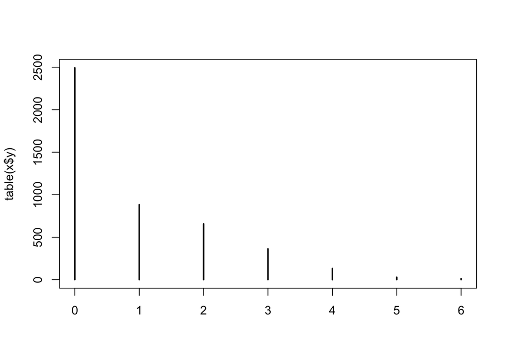

```r
## a new data frame for analysis
x <- josm$surveys
x$y <- ytot[rownames(x), spp] # subset the sparse matrix
plot(table(x$y))
```

### Explore predictor variables

Load a raster stack where some of the variables in `x` were coming from

```r
library(sf)                   # simple features
library(raster)               # reading raster files
rr <- stack("data/josm-landcover-hfi2016.grd") # rasters
rr
```

```
## class      : RasterStack
## dimensions : 390, 475, 185250, 10  (nrow, ncol, ncell, nlayers)
## resolution : 1000, 1000  (x, y)
## extent     : 349616.2, 824616.2, 6029532, 6419532  (xmin, xmax, ymin, ymax)
## crs        : +proj=tmerc +lat_0=0 +lon_0=-115 +k=0.9992 +x_0=500000 +y_0=0 +ellps=GRS80 +units=m +no_defs
## names      :      Open,     Water,       Agr,    UrbInd,   SoftLin,     Roads,     Decid,   OpenWet,     Conif,  ConifWet
## min values :         0,         0,         0,         0,         0,         0,         0,         0,         0,         0
## max values : 0.9775925, 1.0000000, 1.0000000, 1.0000000, 0.3354244, 0.7253037, 1.0000000, 0.9992149, 1.0000000, 1.0000000
```

Let’s create a simple feature object matching the raster projection

```r
xy <- st_as_sf(x,
    coords = c("Longitude", "Latitude"),
    crs = 4269) # NAD83 EPSG:4269
## NAD83 / Alberta 10-TM (Forest) EPSG:3400
xy <- st_transform(xy, st_crs(rr))
```

Put the locations on the map:

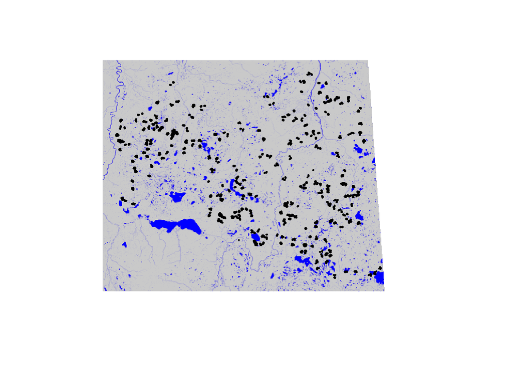

```r
col <- colorRampPalette(c("lightgrey", "blue"))(100)
plot(rr[["Water"]], col=col, axes=FALSE, box=FALSE, legend=FALSE)
plot(xy$geometry, add=TRUE, pch=19, cex=0.2)
```

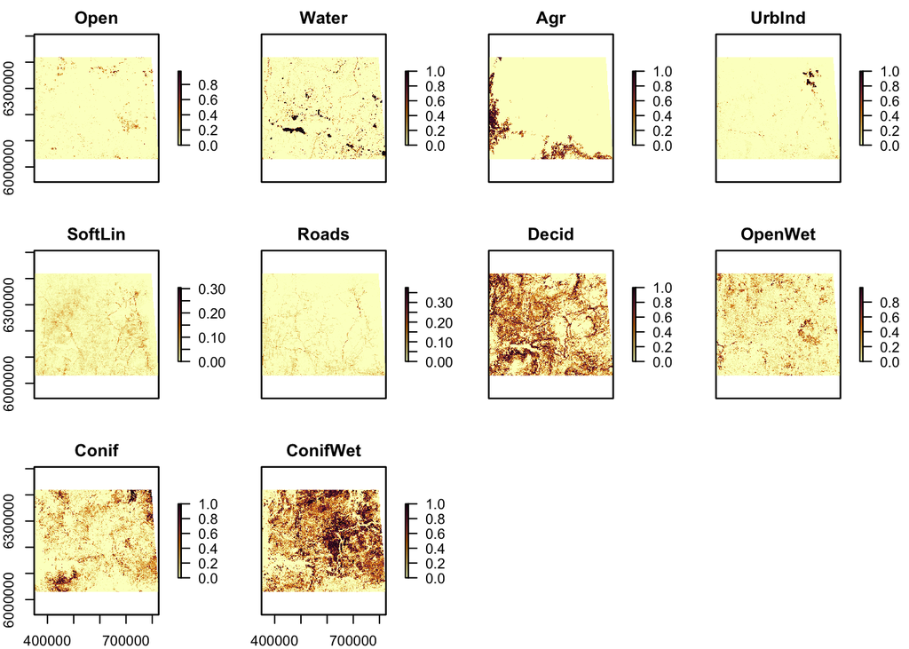

```r
## some visible features: Piece River, Athabasca, Lesser Slave Lake

plot(rr, col=hcl.colors(50, "Lajolla"))
```

### Derived variables

Add up some of the compositional variables into meaningful units:

```r
x$FOR <- x$Decid + x$Conif+ x$ConifWet # forest
x$AHF <- x$Agr + x$UrbInd + x$Roads # 'alienating' human footprint
x$WET <- x$OpenWet + x$ConifWet + x$Water # wet + water
```

Classify surveys locations based on dominant land cover type: this is a shortcut that pays off when it comes to predicting at spatial scales different than the scale where proportion info is coming from

```r
## define column names
cn <- c("Open", "Water", "Agr", "UrbInd", "SoftLin", "Roads", "Decid",
  "OpenWet", "Conif", "ConifWet")
## these sum to 1
summary(rowSums(x[,cn]))
```

```
##    Min. 1st Qu.  Median    Mean 3rd Qu.    Max.
##       1       1       1       1       1       1
```

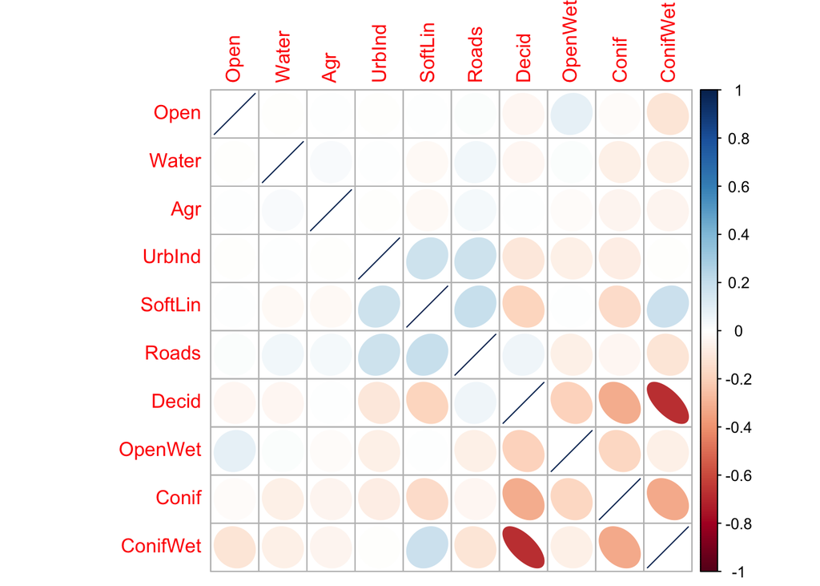

```r
## see how these are correlated
corrplot::corrplot(cor(x[,cn]), "ellipse")
```

The `find_max()` function finds the maximum value in each row, the output containes the value and the column where it was found, which is exactly the info we need

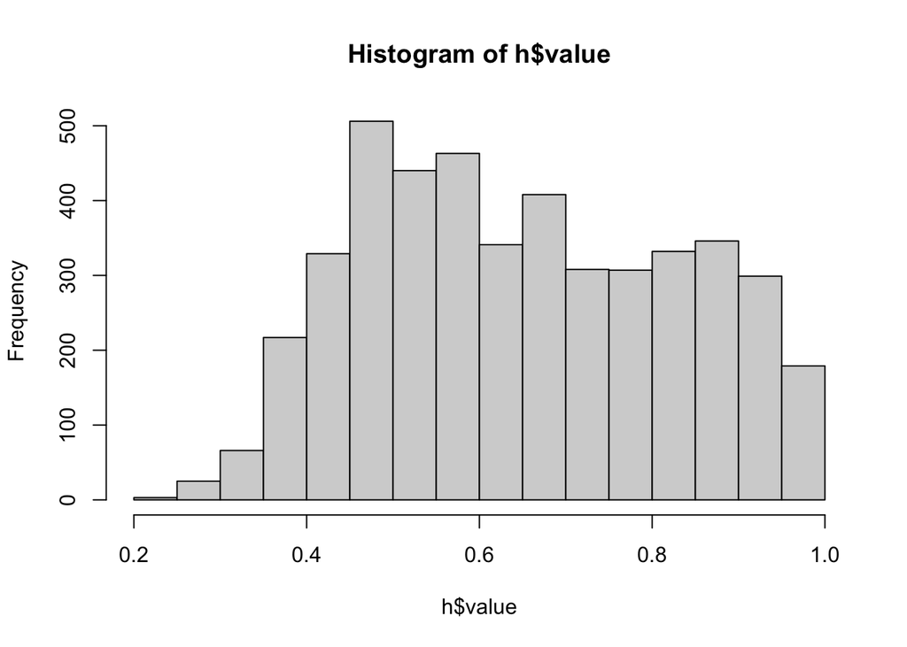

```r
h <- find_max(x[,cn])
hist(h$value)
```

```r
table(h$index)
```

```
##
##     Open    Water      Agr   UrbInd  SoftLin
##       12       10        4       14        0
##    Roads    Decid  OpenWet    Conif ConifWet
##        2     2084      160      745     1538
```

```r
x$HAB <- droplevels(h$index) # drop empty levels
```

We can use the value to exclude sites that do not contain at least a certain proportion of the dominant land cover type (e.g. <25%), or we can use this info to assign less weight to such “contaminated” sites (i.e. the dominant land cover is contaminated by other cover types). Finding dominant land cover is is more meaningful at smaller spacial scales.

### Exercise

1. Look at individual continuous variables using `summary()`, `hist()`
2. Look at discrete variables using `table()`
3. Explore bivariate relationships between continuous variables using `plot()`
4. Explore bivariate relationships between continuous and discrete variables using `boxplot()`
5. Explore multivariate relationships using scatterplot matrix (`plot()`)